# **Priming Mindfulness Project 3**

### State Hostility

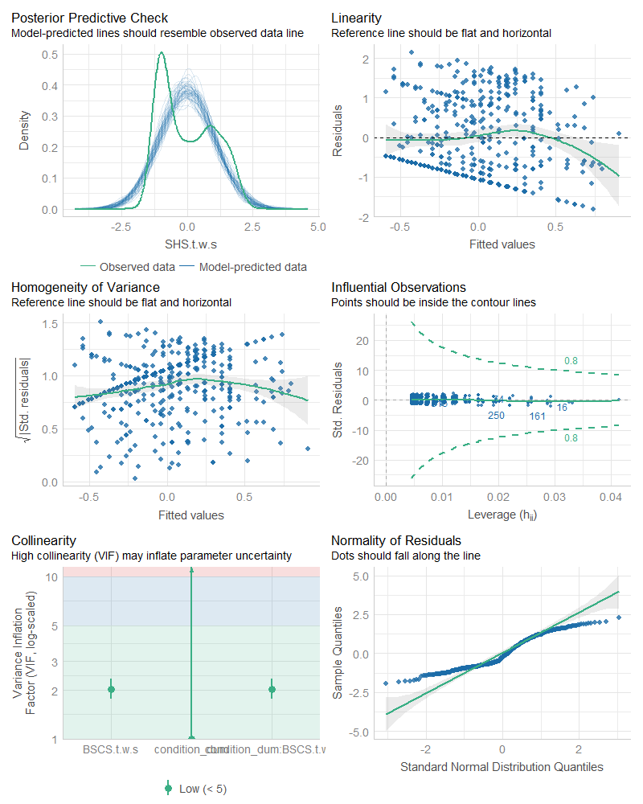

```r
mod4 <- lm(SHS.t.w.s ~ condition_dum*BSCS.t.w.s,
           data = data, na.action="na.exclude")
check_model(mod4)
```

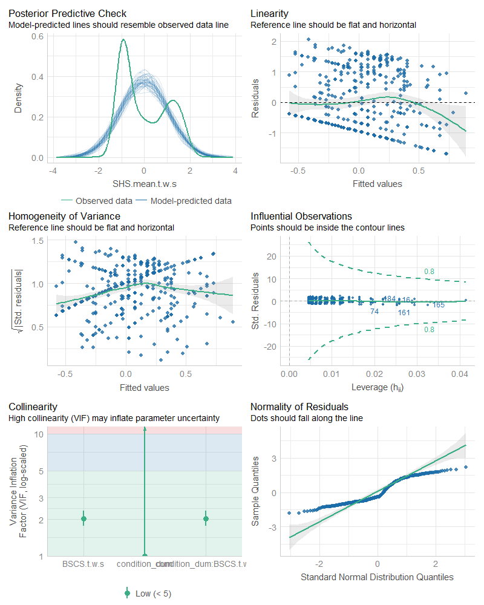

```r
mod5 <- lm(SHS.mean.t.w.s ~ condition_dum*BSCS.t.w.s,
           data = data, na.action="na.exclude")
check_model(mod5)
```

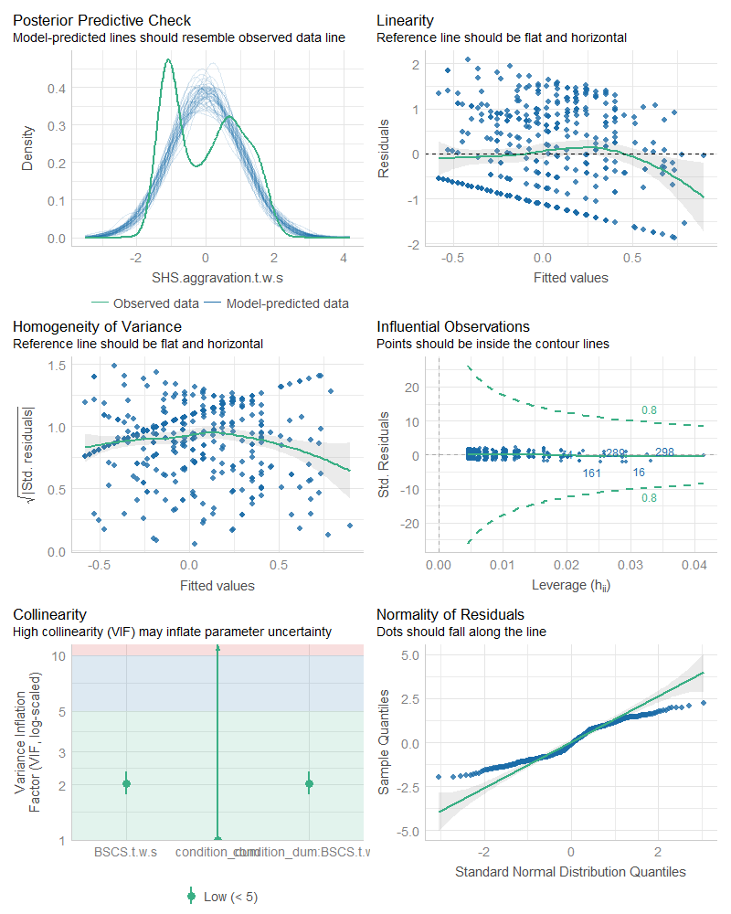

```r
mod6 <- lm(SHS.aggravation.t.w.s ~ condition_dum*BSCS.t.w.s,
           data = data, na.action="na.exclude")
check_model(mod6)
```

All the models assumptions look pretty good overall actually, even with all these variables. The lines for linearity and homoscedasticity are a bit skewed but nothing too crazy. Let’s now look at the results.

## Moderations

### Intensity * Duration

```r
mod1 %>%
  nice_lm() %>%
  nice_table(highlight = TRUE)
```

| Dependent Variable | Predictor | df | β | t | p | sr2 | 95% CI |
| --- | --- | --- | --- | --- | --- | --- | --- |
| blastintensity.duration.t.w.s | condition_dum | 428 | 0.04 | 0.45 | .650 | .00 | [0.00, 0.00] |
|  | BSCS.t.w.s | 428 | -0.07 | -1.06 | .291 | .00 | [0.00, 0.01] |
|  | condition_dum × BSCS.t.w.s | 428 | 0.16 | 1.64 | .101 | .01 | [0.00, 0.02] |

### State Hostility

```r
list(mod4, mod5, mod6) %>%
  nice_lm() %>%
  nice_table(highlight = TRUE)
```

| Dependent Variable | Predictor | df | β | t | p | sr2 | 95% CI |
| --- | --- | --- | --- | --- | --- | --- | --- |
| SHS.t.w.s | condition_dum | 428 | -0.01 | -0.16 | .876 | .00 | [0.00, 0.00] |
|  | BSCS.t.w.s | 428 | -0.31 | -4.84 | < .001*** | .05 | [0.01, 0.09] |
|  | condition_dum × BSCS.t.w.s | 428 | -0.01 | -0.13 | .900 | .00 | [0.00, 0.00] |
| SHS.mean.t.w.s | condition_dum | 428 | -0.01 | -0.10 | .924 | .00 | [0.00, 0.00] |
|  | BSCS.t.w.s | 428 | -0.29 | -4.45 | < .001*** | .04 | [0.01, 0.08] |
|  | condition_dum × BSCS.t.w.s | 428 | -0.03 | -0.30 | .768 | .00 | [0.00, 0.00] |
| SHS.aggravation.t.w.s | condition_dum | 428 | -0.01 | -0.11 | .915 | .00 | [0.00, 0.00] |
|  | BSCS.t.w.s | 428 | -0.31 | -4.79 | < .001*** | .05 | [0.01, 0.09] |
|  | condition_dum × BSCS.t.w.s | 428 | -0.01 | -0.10 | .916 | .00 | [0.00, 0.00] |

### Affect

```r
list(mod2, mod3) %>%
  nice_lm() %>%
  nice_table(highlight = TRUE)
```

| Dependent Variable | Predictor | df | β | t | p | sr2 | 95% CI |
| --- | --- | --- | --- | --- | --- | --- | --- |
| PANAS_pos.t.w.s | condition_dum | 428 | -0.03 | -0.36 | .717 | .00 | [0.00, 0.00] |
|  | BSCS.t.w.s | 428 | 0.20 | 3.01 | .003** | .02 | [0.00, 0.05] |
|  | condition_dum × BSCS.t.w.s | 428 | 0.02 | 0.19 | .846 | .00 | [0.00, 0.00] |
| PANAS_neg.t.w.s | condition_dum | 428 | -0.05 | -0.59 | .556 | .00 | [0.00, 0.01] |
|  | BSCS.t.w.s | 428 | -0.28 | -4.26 | < .001*** | .04 | [0.00, 0.07] |
|  | condition_dum × BSCS.t.w.s | 428 | -0.09 | -1.04 | .301 | .00 | [0.00, 0.01] |

> **Interpretation:** The condition by trait self-control (brief self-control scale, BSCS) interaction does not come up.

## Interaction plots

Let’s plot the main interaction(s).

### Intensity * Duration

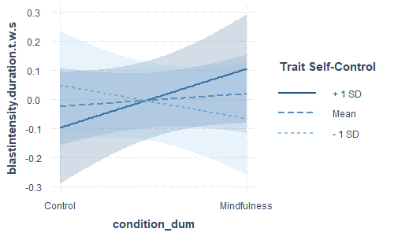

```r
interact_plot(mod1, pred = "condition_dum", modx = "BSCS.t.w.s",
              modxvals = NULL, interval = TRUE, x.label = "condition_dum",
              pred.labels = c("Control", "Mindfulness"),
              legend.main = "Trait Self-Control")
```

> **Interpretation:** It appears that there are no interactions.

# Moderations (exploratory)

Let’s see if our variables don’t interact together with our experimental condition. But first, let’s test the models assumptions.

## Assumptions

### Intensity * Duration

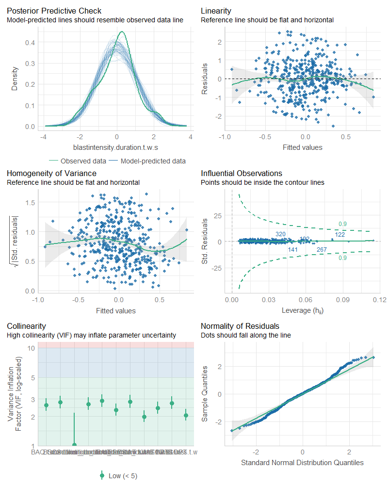

```r
mod1 <- lm(blastintensity.duration.t.w.s ~ condition_dum*KIMS.t.w.s +
             condition_dum*BSCS.t.w.s + condition_dum*BAQ.t.w.s +
             condition_dum*SOPT.t.w.s + condition_dum*IAT.t.w.s,
           data = data, na.action="na.exclude")
check_model(mod1)
```

### Affect

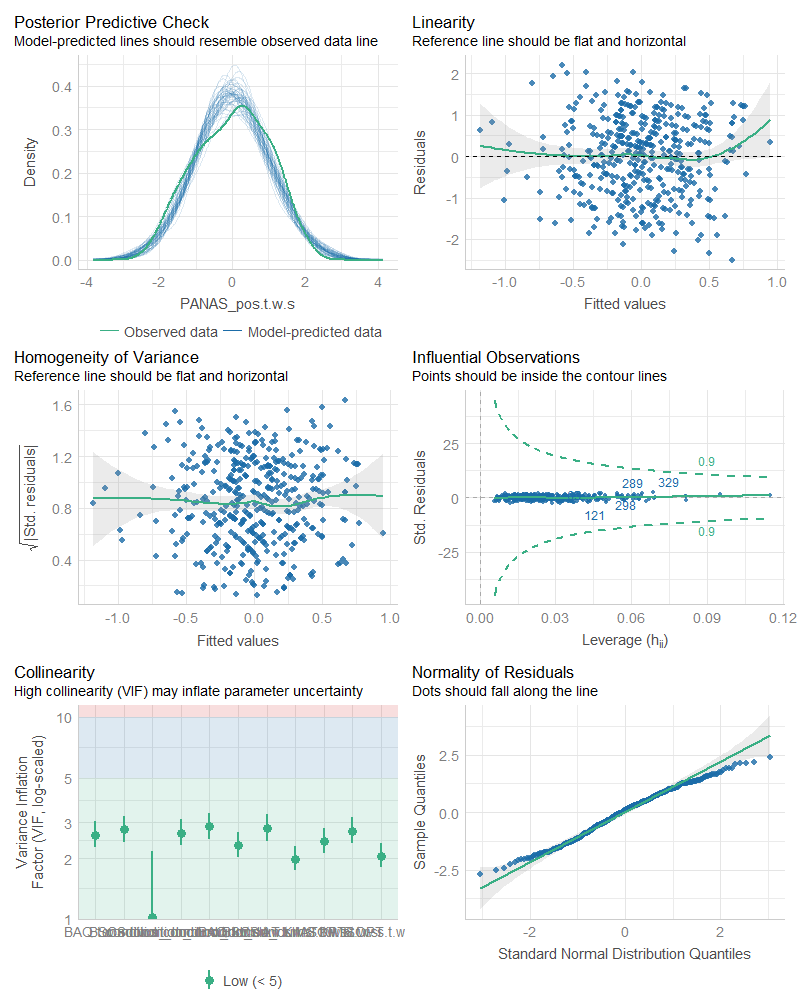

```r
mod2 <- lm(PANAS_pos.t.w.s ~ condition_dum*KIMS.t.w.s +
             condition_dum*BSCS.t.w.s + condition_dum*BAQ.t.w.s +
             condition_dum*SOPT.t.w.s + condition_dum*IAT.t.w.s,
           data = data, na.action="na.exclude")
check_model(mod2)
```

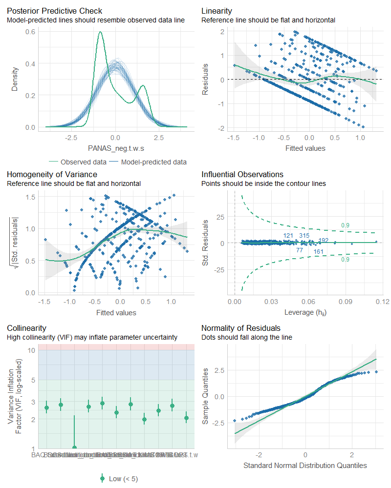

```r
mod3 <- lm(PANAS_neg.t.w.s ~ condition_dum*KIMS.t.w.s +
             condition_dum*BSCS.t.w.s + condition_dum*BAQ.t.w.s +
             condition_dum*SOPT.t.w.s + condition_dum*IAT.t.w.s,
           data = data, na.action="na.exclude")
check_model(mod3)
```

### State Hostility

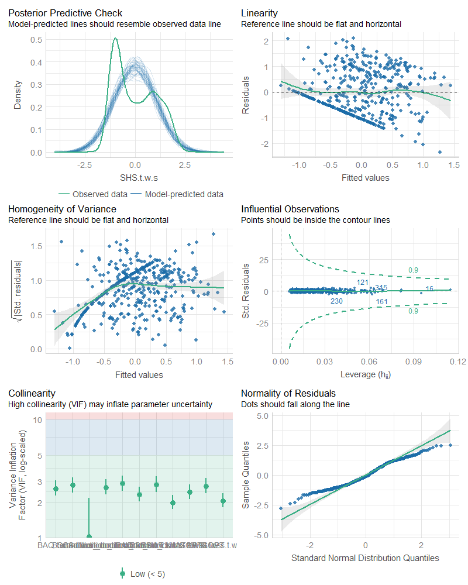

```r
mod4 <- lm(SHS.t.w.s ~ condition_dum*KIMS.t.w.s +
             condition_dum*BSCS.t.w.s + condition_dum*BAQ.t.w.s +
             condition_dum*SOPT.t.w.s + condition_dum*IAT.t.w.s,
           data = data, na.action="na.exclude")
check_model(mod4)
```

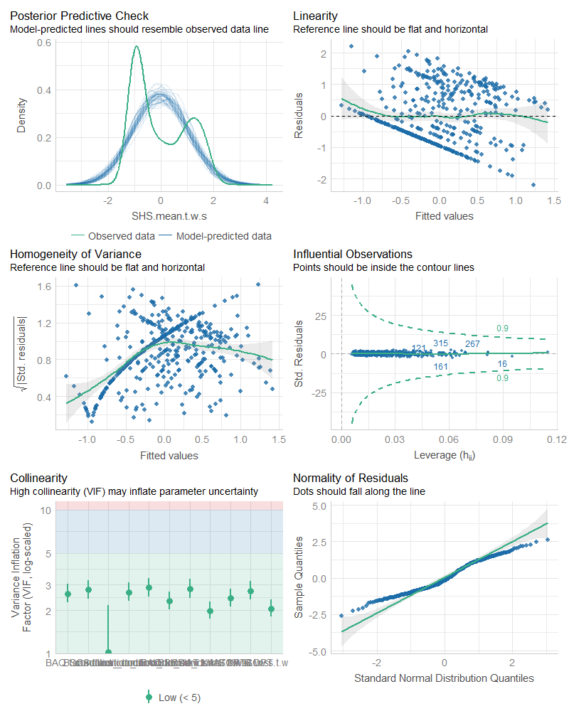

```r
mod5 <- lm(SHS.mean.t.w.s ~ condition_dum*KIMS.t.w.s +
             condition_dum*BSCS.t.w.s + condition_dum*BAQ.t.w.s +
             condition_dum*SOPT.t.w.s + condition_dum*IAT.t.w.s,
           data = data, na.action="na.exclude")
check_model(mod5)
```

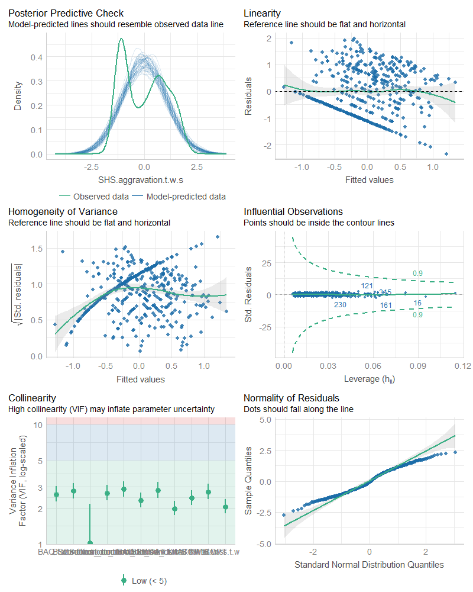

```r
mod6 <- lm(SHS.aggravation.t.w.s ~ condition_dum*KIMS.t.w.s +
             condition_dum*BSCS.t.w.s + condition_dum*BAQ.t.w.s +
             condition_dum*SOPT.t.w.s + condition_dum*IAT.t.w.s,
           data = data, na.action="na.exclude")
check_model(mod6)
```

All the models assumptions look pretty good overall actually, even with all these variables. The lines for linearity and homoscedasticity are a bit skewed but nothing too crazy. Let’s now look at the results.

## Moderations

### Intensity * Duration

```r
mod1 %>%
  nice_lm() %>%
  nice_table(highlight = TRUE)
```

| Dependent Variable | Predictor | df | β | t | p | sr2 | 95% CI |
| --- | --- | --- | --- | --- | --- | --- | --- |
| blastintensity.duration.t.w.s | condition_dum | 420 | 0.05 | 0.58 | .562 | .00 | [0.00, 0.01] |
|  | KIMS.t.w.s | 420 | 0.06 | 0.84 | .403 | .00 | [0.00, 0.01] |
|  | BSCS.t.w.s | 420 | 0.02 | 0.32 | .750 | .00 | [0.00, 0.00] |
|  | BAQ.t.w.s | 420 | 0.20 | 2.69 | .008** | .02 | [0.00, 0.04] |
|  | SOPT.t.w.s | 420 | 0.15 | 2.31 | .021* | .01 | [0.00, 0.03] |
|  | IAT.t.w.s | 420 | -0.08 | -1.12 | .264 | .00 | [0.00, 0.01] |
|  | condition_dum × KIMS.t.w.s | 420 | 0.03 | 0.30 | .768 | .00 | [0.00, 0.00] |
|  | condition_dum × BSCS.t.w.s | 420 | 0.12 | 1.11 | .268 | .00 | [0.00, 0.01] |
|  | condition_dum × BAQ.t.w.s | 420 | 0.05 | 0.50 | .617 | .00 | [0.00, 0.00] |
|  | condition_dum × SOPT.t.w.s | 420 | 0.00 | 0.02 | .985 | .00 | [0.00, 0.00] |
|  | condition_dum × IAT.t.w.s | 420 | 0.12 | 1.26 | .207 | .00 | [0.00, 0.01] |

### Affect

```r
list(mod2, mod3) %>%
  nice_lm() %>%
  nice_table(highlight = TRUE)
```

| Dependent Variable | Predictor | df | β | t | p | sr2 | 95% CI |
| --- | --- | --- | --- | --- | --- | --- | --- |
| PANAS_pos.t.w.s | condition_dum | 420 | -0.01 | -0.10 | .919 | .00 | [0.00, 0.00] |
|  | KIMS.t.w.s | 420 | 0.29 | 3.78 | < .001*** | .03 | [0.00, 0.06] |
|  | BSCS.t.w.s | 420 | 0.14 | 1.80 | .073 | .01 | [0.00, 0.02] |
|  | BAQ.t.w.s | 420 | 0.12 | 1.56 | .119 | .01 | [0.00, 0.02] |
|  | SOPT.t.w.s | 420 | 0.07 | 1.04 | .297 | .00 | [0.00, 0.01] |
|  | IAT.t.w.s | 420 | 0.06 | 0.88 | .380 | .00 | [0.00, 0.01] |
|  | condition_dum × KIMS.t.w.s | 420 | 0.01 | 0.06 | .955 | .00 | [0.00, 0.00] |
|  | condition_dum × BSCS.t.w.s | 420 | -0.02 | -0.20 | .838 | .00 | [0.00, 0.00] |
|  | condition_dum × BAQ.t.w.s | 420 | -0.02 | -0.23 | .820 | .00 | [0.00, 0.00] |
|  | condition_dum × SOPT.t.w.s | 420 | 0.02 | 0.17 | .868 | .00 | [0.00, 0.00] |
|  | condition_dum × IAT.t.w.s | 420 | -0.04 | -0.40 | .691 | .00 | [0.00, 0.00] |
| PANAS_neg.t.w.s | condition_dum | 420 | -0.05 | -0.62 | .535 | .00 | [0.00, 0.01] |
|  | KIMS.t.w.s | 420 | -0.29 | -4.10 | < .001*** | .03 | [0.00, 0.06] |
|  | BSCS.t.w.s | 420 | -0.05 | -0.73 | .469 | .00 | [0.00, 0.01] |
|  | BAQ.t.w.s | 420 | 0.24 | 3.54 | < .001*** | .02 | [0.00, 0.05] |
|  | SOPT.t.w.s | 420 | 0.01 | 0.10 | .919 | .00 | [0.00, 0.00] |
|  | IAT.t.w.s | 420 | -0.04 | -0.58 | .563 | .00 | [0.00, 0.00] |
|  | condition_dum × KIMS.t.w.s | 420 | 0.02 | 0.25 | .805 | .00 | [0.00, 0.00] |
|  | condition_dum × BSCS.t.w.s | 420 | -0.11 | -1.06 | .290 | .00 | [0.00, 0.01] |
|  | condition_dum × BAQ.t.w.s | 420 | -0.06 | -0.62 | .535 | .00 | [0.00, 0.01] |
|  | condition_dum × SOPT.t.w.s | 420 | 0.14 | 1.61 | .108 | .00 | [0.00, 0.02] |
|  | condition_dum × IAT.t.w.s | 420 | 0.01 | 0.16 | .874 | .00 | [0.00, 0.00] |

### State Hostility

```r
list(mod4, mod5, mod6) %>%
  nice_lm() %>%
  nice_table(highlight = TRUE)
```

| Dependent Variable | Predictor | df | β | t | p | sr2 | 95% CI |
| --- | --- | --- | --- | --- | --- | --- | --- |
| SHS.t.w.s | condition_dum | 420 | -0.03 | -0.34 | .737 | .00 | [0.00, 0.00] |
|  | KIMS.t.w.s | 420 | -0.24 | -3.49 | .001*** | .02 | [0.00, 0.04] |
|  | BSCS.t.w.s | 420 | -0.07 | -1.08 | .283 | .00 | [0.00, 0.01] |
|  | BAQ.t.w.s | 420 | 0.25 | 3.75 | < .001*** | .02 | [0.00, 0.05] |
|  | SOPT.t.w.s | 420 | 0.11 | 1.87 | .062 | .01 | [0.00, 0.02] |
|  | IAT.t.w.s | 420 | -0.11 | -1.71 | .088 | .01 | [0.00, 0.02] |
|  | condition_dum × KIMS.t.w.s | 420 | 0.04 | 0.44 | .663 | .00 | [0.00, 0.00] |
|  | condition_dum × BSCS.t.w.s | 420 | -0.03 | -0.30 | .766 | .00 | [0.00, 0.00] |
|  | condition_dum × BAQ.t.w.s | 420 | 0.00 | 0.02 | .987 | .00 | [0.00, 0.00] |
|  | condition_dum × SOPT.t.w.s | 420 | 0.07 | 0.88 | .381 | .00 | [0.00, 0.01] |
|  | condition_dum × IAT.t.w.s | 420 | 0.03 | 0.36 | .720 | .00 | [0.00, 0.00] |
| SHS.mean.t.w.s | condition_dum | 420 | -0.02 | -0.25 | .806 | .00 | [0.00, 0.00] |
|  | KIMS.t.w.s | 420 | -0.23 | -3.30 | .001** | .02 | [0.00, 0.04] |
|  | BSCS.t.w.s | 420 | -0.05 | -0.72 | .473 | .00 | [0.00, 0.01] |
|  | BAQ.t.w.s | 420 | 0.26 | 3.78 | < .001*** | .03 | [0.00, 0.05] |
|  | SOPT.t.w.s | 420 | 0.13 | 2.24 | .026* | .01 | [0.00, 0.02] |
|  | IAT.t.w.s | 420 | -0.12 | -1.78 | .075 | .01 | [0.00, 0.02] |
|  | condition_dum × KIMS.t.w.s | 420 | 0.07 | 0.72 | .471 | .00 | [0.00, 0.01] |
|  | condition_dum × BSCS.t.w.s | 420 | -0.06 | -0.55 | .580 | .00 | [0.00, 0.00] |
|  | condition_dum × BAQ.t.w.s | 420 | 0.03 | 0.28 | .777 | .00 | [0.00, 0.00] |
|  | condition_dum × SOPT.t.w.s | 420 | 0.08 | 0.92 | .360 | .00 | [0.00, 0.01] |
|  | condition_dum × IAT.t.w.s | 420 | 0.05 | 0.56 | .573 | .00 | [0.00, 0.00] |
| SHS.aggravation.t.w.s | condition_dum | 420 | -0.02 | -0.25 | .800 | .00 | [0.00, 0.00] |
|  | KIMS.t.w.s | 420 | -0.24 | -3.36 | .001*** | .02 | [0.00, 0.04] |
|  | BSCS.t.w.s | 420 | -0.09 | -1.28 | .203 | .00 | [0.00, 0.01] |
|  | BAQ.t.w.s | 420 | 0.24 | 3.48 | .001*** | .02 | [0.00, 0.05] |
|  | SOPT.t.w.s | 420 | 0.07 | 1.20 | .230 | .00 | [0.00, 0.01] |
|  | IAT.t.w.s | 420 | -0.09 | -1.39 | .166 | .00 | [0.00, 0.01] |
|  | condition_dum × KIMS.t.w.s | 420 | 0.01 | 0.13 | .897 | .00 | [0.00, 0.00] |
|  | condition_dum × BSCS.t.w.s | 420 | -0.02 | -0.18 | .854 | .00 | [0.00, 0.00] |
|  | condition_dum × BAQ.t.w.s | 420 | -0.03 | -0.29 | .771 | .00 | [0.00, 0.00] |
|  | condition_dum × SOPT.t.w.s | 420 | 0.08 | 0.98 | .330 | .00 | [0.00, 0.01] |
|  | condition_dum × IAT.t.w.s | 420 | 0.02 | 0.22 | .822 | .00 | [0.00, 0.00] |

> **Interpretation:** The condition by trait self-control (brief self-control scale, BSCS) interaction does not come up.

## Interaction plots

Let’s plot the interaction of interest.

### Intensity * Duration

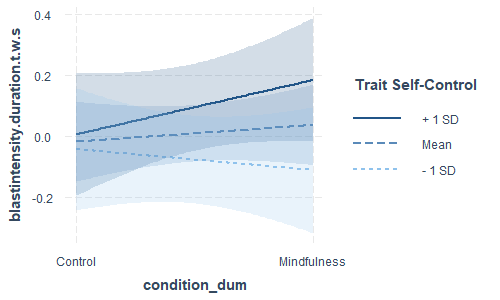

```r
interact_plot(mod1, pred = "condition_dum", modx = "BSCS.t.w.s",
              modxvals = NULL, interval = TRUE, x.label = "condition_dum",
              pred.labels = c("Control", "Mindfulness"),
              legend.main = "Trait Self-Control")
```

# Conclusions

Based on the results, it seems that the predicted interaction between self-control and the priming mindfulness manipulation does not come up. The exploratory analyses including the larger models also did not show the expected effects.

# Full Code

The full script of executive code contained in this document is reproduced here.

```r
library(rempsyc)
library(dplyr)
library(interactions)
library(performance)
library(see)
library(report)
library(datawizard)
library(bestNormalize)
library(psych)
library(visdat)
library(missForest)
library(doParallel)
library(naniar)

summary(report(sessionInfo()))

# Read data
data <- read.table("https://osf.io/c5b7r/?action=download", sep = "\t", header = TRUE)

# Code group variable as factor
data <- data %>%
  mutate(condition_dum = ifelse(condition == "Mindfulness", 1, 0),
         condition = as.factor(condition))
# Dummy variable (instead of factor) is required by the `interact_plot()` function...

cat(report_participants(data, threshold = 1))

# Allocation ratio
report(data$condition)

# Make list of DVs
col.list <- c("blastintensity.duration", "KIMS", "BSCS", "BAQ", "SHS", "SHS.mean",
              "SHS.aggravation", "PANAS_pos", "PANAS_neg", "IAT", "SOPT")

report::cite_packages(sessionInfo())

data %>%
    summarize(success.80 = sum(manipsuccessleft < .80,
                               na.rm = TRUE),
              is.na = sum(is.na(manipsuccessleft)))

data <- data %>%
    filter(manipsuccessleft >= .80)
cat(report_participants(data, threshold = 1))

data <- data %>%
    mutate(att_check = rowSums(
      select(., att_check1, att_check2, att_check3)))

data %>%
  count(att_check)

data <- data %>%
  filter(att_check >= 2)

cat(report_participants(data, threshold = 1))

report(data$condition)

# Check final level of English
data %>%
  count(english_7)

# Check for nice_na
nice_na(data, scales = c("BSCS", "BAQ", "KIMS", "PANAS", "SHS"))


# Smaller subset of data for easier inspection
data %>%
  select(country.ip:att_check) %>%
  vis_miss

# Let's use Little's MCAR test to confirm
# We have to proceed by "scale" because the function can only
# support 30 variables max at a time
data %>%
  select(BSCS_1:BSCS_7) %>%
  mcar_test
# a p-value of 0 means the test failed because there's no missing values.

data %>%
  select(BAQ_1:BAQ_12) %>%
  mcar_test
# a p-value of 0 means the test failed because there's no missing values.

data %>%
  select(KIMS_1:KIMS_20) %>%
  mcar_test
# a p-value of 0 means the test failed because there's no missing values.

data %>%
  select(KIMS_21:KIMS_39) %>%
  mcar_test
# a p-value of 0 means the test failed because there's no missing values.

data %>%
  select(PANAS_1:PANAS_10) %>%
  mcar_test
# a p-value of 0 means the test failed because there's no missing values.

data %>%
  select(SHS_1:SHS_21) %>%
  mcar_test
# a p-value of 0 means the test failed because there's no missing values.


# Need character variables as factors
# "Error: Can not handle categorical predictors with more than 53 categories."
# So we have to temporarily remove IDs also...
new.data <- data %>%
  select(-c(att_check1, att_check2, att_check3, att_check)) %>%
  mutate(across(where(is.character), as.factor))

# Parallel processing
registerDoParallel(cores = 4)

# Variables
set.seed(100)
data.imp <- missForest(new.data, verbose = TRUE, parallelize = "variables")
# Total time is 2 sec (4*0.5) - 4 cores

# Extract imputed dataset
new.data <- data.imp$ximp

# Add back the NAs in country, attention checks, etc.
data <- new.data %>%
  mutate(country.ip = data$country.ip,
         gender = data$gender,
         att_check1 = data$att_check1,
         att_check2 = data$att_check2,
         att_check3 = data$att_check3,
         att_check = data$att_check)

# Reverse code BSCS items 2, 4, 6, 7
data <- data %>%
  mutate(across(starts_with("BSCS"), .names = "{col}r"))
data <- data %>%
  mutate(across(c(BSCS_2, BSCS_4, BSCS_6, BSCS_7), ~nice_reverse(.x, 5), .names = "{col}r"))

# Get mean BSCS
data <- data %>%
  mutate(BSCS = rowMeans(select(., BSCS_1r:BSCS_7r)))

# Reverse code BAQ item 7
data <- data %>%
  mutate(across(starts_with("BAQ"), .names = "{col}r"))

data <- data %>%
  mutate(across(BAQ_7, ~nice_reverse(.x, 7), .names = "{col}r"))

# Get sum of BAQ
data <- data %>%
  mutate(BAQ = rowMeans(select(., BAQ_1r:BAQ_12r)))

# Reverse code KIMS items 3-4, 8, 11-12, 14, 16, 18, 20, 22, 23-24, 27-28, 31-32, 35-36
data <- data %>%
  mutate(across(starts_with("KIMS"), .names = "{col}r"))

data <- data %>%
  mutate(across(all_of(paste0("KIMS_", c(3:4, 8, 11:12, 14, 16, 18, 20,
                                         22:24, 27:28, 31:32, 35:36))),
                ~nice_reverse(.x, 5), .names = "{col}r"))

# Get sum of KIMS
data <- data %>%
  mutate(KIMS = rowMeans(select(., KIMS_1r:KIMS_39r)))

# No reverse scoring needed for PANAS.
data <- data %>%
  mutate(PANAS_pos = rowMeans(select(., paste0("PANAS_", seq(1, 10, 2)))),
         PANAS_neg = rowMeans(select(., paste0("PANAS_", seq(2, 10, 2)))))

# SHS: forgot to add back the two other scales, so no reverse scoring needed.

# Get sum of SHS and subscales
data <- data %>%
  mutate(SHS = rowMeans(select(., SHS_1:SHS_21)),
         SHS.mean = rowMeans(select(., SHS_1:SHS_14)),
         SHS.aggravation = rowMeans(select(., SHS_14:SHS_21)))

# Create new variable blastintensity.duration
data <- data %>%
  mutate(blastintensity.duration = blastintensity * blastduration)

data %>%
  select(BSCS_1r:BSCS_7r) %>%
  omega(nfactors = 1)

data %>%
  select(BAQ_1r:BAQ_12r) %>%
  omega(nfactors = 1)

data %>%
  select(KIMS_1r:KIMS_39r) %>%
  omega(nfactors = 1)

data %>%
  select(SHS_1:SHS_21) %>%
  omega(nfactors = 2)

# PANAS_pos
data %>%
  select(paste0("PANAS_", seq(1, 10, 2))) %>%
  omega(nfactors = 1)

# PANAS_neg
data %>%
  select(paste0("PANAS_", seq(2, 10, 2))) %>%
  omega(nfactors = 1)

lapply(col.list, function(x)
  nice_normality(data,
                 variable = x,
                 title = x,
                 group = "condition",
                 shapiro = TRUE,
                 histogram = TRUE))

predict_bestNormalize <- function(var) {
  x <- bestNormalize(var, standardize = FALSE, allow_orderNorm = FALSE)
  print(cur_column())
  print(x$chosen_transform)
  cat("\n")
  predict(x)
}

set.seed(100)
data <- data %>%
  mutate(across(all_of(col.list),
                predict_bestNormalize,
                .names = "{.col}.t"))
col.list <- paste0(col.list, ".t")
```

```r
# Group normality
lapply(col.list, function(x)
  nice_normality(data,
                 x,
                 "condition",
                 shapiro = TRUE,
                 title = x,
                 histogram = TRUE))

# Plotting variance
plots(lapply(col.list, function(x) {
  nice_varplot(data, x, group = "condition")
  }),
  n_columns = 3)


plots(lapply(col.list, function(x) {
  plot_outliers(data, x, group = "condition", ytitle = x, binwidth = 0.15)
  }),
  n_columns = 2)

data %>%
  filter(condition == "Control") %>%
  find_mad(col.list, criteria = 3)

data %>%
  filter(condition == "Mindfulness") %>%
  find_mad(col.list, criteria = 3)

data.na <- na.omit(data[col.list])
x <- check_outliers(data.na, method = "mcd",
                    threshold = 200)
x

plot(x)

# Winsorize variables of interest with MAD
data <- data %>%
  group_by(condition) %>%
  mutate(across(all_of(col.list),
                winsorize_mad,
                .names = "{.col}.w")) %>%
  ungroup()

col.list <- paste0(col.list, ".w")

data <- data %>%
  mutate(across(all_of(col.list), standardize, .names = "{col}.s"))

# Update col.list
col.list <- paste0(col.list, ".s")

nice_t_test(data,
            response = col.list,
            group = "condition") %>%
  nice_table(highlight = 0.10, width = .80)

skewed <- c("SHS", "SHS.mean", "SHS.aggravation", "PANAS_neg")

lapply(skewed, \(x) {
  forms <- as.formula(paste(x, "~", "condition"))
  y <- wilcox.test(forms, data = data) %>%
    report(data = data)
  print(y)
  as.data.frame(y)
}) %>%
  bind_rows() %>%
  nice_table(highlight = TRUE)

nice_violin(data,
            group = "condition",
            response = "blastintensity.duration.t.w.s",
            comp1 = 1,
            comp2 = 2,
            obs = TRUE,
            has.d = TRUE,
            d.y = 1)

data %>%
    group_by(condition) %>%
    summarize(M = mean(blastintensity.duration),
              SD = sd(blastintensity.duration),
              N = n()) %>%
  nice_table(width = 0.40)

mod1 <- lm(blastintensity.duration.t.w.s ~ condition_dum*BSCS.t.w.s,
           data = data, na.action="na.exclude")
check_model(mod1)

mod2 <- lm(PANAS_pos.t.w.s ~ condition_dum*BSCS.t.w.s,
           data = data, na.action="na.exclude")
check_model(mod2)

mod3 <- lm(PANAS_neg.t.w.s ~ condition_dum*BSCS.t.w.s,
           data = data, na.action="na.exclude")
check_model(mod3)

mod4 <- lm(SHS.t.w.s ~ condition_dum*BSCS.t.w.s,
           data = data, na.action="na.exclude")
check_model(mod4)

mod5 <- lm(SHS.mean.t.w.s ~ condition_dum*BSCS.t.w.s,
           data = data, na.action="na.exclude")
check_model(mod5)

mod6 <- lm(SHS.aggravation.t.w.s ~ condition_dum*BSCS.t.w.s,
           data = data, na.action="na.exclude")
check_model(mod6)

mod1 %>%
  nice_lm() %>%
  nice_table(highlight = TRUE)

# Save table for paper
list(mod1, mod2, mod3, mod4, mod5, mod6) %>%
  nice_lm() %>%
  mutate(`Dependent Variable` = rep(c(
    "Aggression", "Positive Affect", "Negative Affect", "State Hostility",
    "State Hostility (feeling mean)", "State Hostility (aggravation)"), each = 3),
         Predictor = text_remove(.data$Predictor, "_dum") %>%
           text_remove(".t.w.s")) %>%
  nice_table(
    highlight = TRUE,
    title = c("Table 5", "Testing the Condition × Self-Control Interaction"),
    note = c("Aggression refers to the product of blast intensity and blast duration in the Competitive Reaction Time Task (CRTT). BSCS: trait self-control. There are no significant interactions.",
    "** p < .01, *** p < .001. Rows with grey shading indicate statistical significance.")) %>%
  flextable::save_as_docx(path = "modtable1.docx")

list(mod4, mod5, mod6) %>%
  nice_lm() %>%
  nice_table(highlight = TRUE)

list(mod2, mod3) %>%
  nice_lm() %>%
  nice_table(highlight = TRUE)

interact_plot(mod1, pred = "condition_dum", modx = "BSCS.t.w.s",
              modxvals = NULL, interval = TRUE, x.label = "condition_dum",
              pred.labels = c("Control", "Mindfulness"),
              legend.main = "Trait Self-Control")

mod1 <- lm(blastintensity.duration.t.w.s ~ condition_dum*KIMS.t.w.s +
             condition_dum*BSCS.t.w.s + condition_dum*BAQ.t.w.s +
             condition_dum*SOPT.t.w.s + condition_dum*IAT.t.w.s,
           data = data, na.action="na.exclude")
check_model(mod1)

mod2 <- lm(PANAS_pos.t.w.s ~ condition_dum*KIMS.t.w.s +
             condition_dum*BSCS.t.w.s + condition_dum*BAQ.t.w.s +
             condition_dum*SOPT.t.w.s + condition_dum*IAT.t.w.s,
           data = data, na.action="na.exclude")
check_model(mod2)

mod3 <- lm(PANAS_neg.t.w.s ~ condition_dum*KIMS.t.w.s +
             condition_dum*BSCS.t.w.s + condition_dum*BAQ.t.w.s +
             condition_dum*SOPT.t.w.s + condition_dum*IAT.t.w.s,
           data = data, na.action="na.exclude")
check_model(mod3)

mod4 <- lm(SHS.t.w.s ~ condition_dum*KIMS.t.w.s +
             condition_dum*BSCS.t.w.s + condition_dum*BAQ.t.w.s +
             condition_dum*SOPT.t.w.s + condition_dum*IAT.t.w.s,
           data = data, na.action="na.exclude")
check_model(mod4)

mod5 <- lm(SHS.mean.t.w.s ~ condition_dum*KIMS.t.w.s +
             condition_dum*BSCS.t.w.s + condition_dum*BAQ.t.w.s +
             condition_dum*SOPT.t.w.s + condition_dum*IAT.t.w.s,
           data = data, na.action="na.exclude")
check_model(mod5)

mod6 <- lm(SHS.aggravation.t.w.s ~ condition_dum*KIMS.t.w.s +
             condition_dum*BSCS.t.w.s + condition_dum*BAQ.t.w.s +
             condition_dum*SOPT.t.w.s + condition_dum*IAT.t.w.s,
           data = data, na.action="na.exclude")
check_model(mod6)

mod1 %>%
  nice_lm() %>%
  nice_table(highlight = TRUE)

# Save table for paper
list(mod1, mod2, mod3, mod4, mod5, mod6) %>%
  nice_lm() %>%
  mutate(`Dependent Variable` = rep(c(
    "Aggression", "Positive Affect", "Negative Affect", "State Hostility",
    "State Hostility (feeling mean)", "State Hostility (aggravation)"), each = 11),
         Predictor = text_remove(.data$Predictor, "_dum") %>%
           text_remove(".t.w.s")) %>%
  nice_table(
    highlight = TRUE,
    title = c("Table 6", "Exploring Other Personality Moderators of Priming Mindfulness"),
    note = c("Aggression refers to the product of blast intensity and blast duration in the Competitive Reaction Time Task (CRTT). KIMS: trait mindfulness; BSCS: trait self-control; BAQ: trait aggression; SOPT: working memory; IAT: implicit aggression. There are no significant interactions.",
    "* p < .05, ** p < .01, *** p < .001. Rows with grey shading indicate statistical significance.")) %>%
  flextable::save_as_docx(path = "modtable2.docx")
```

```r
list(mod2, mod3) %>%
  nice_lm() %>%
  nice_table(highlight = TRUE)

list(mod4, mod5, mod6) %>%
  nice_lm() %>%
  nice_table(highlight = TRUE)

interact_plot(mod1, pred = "condition_dum", modx = "BSCS.t.w.s",
              modxvals = NULL, interval = TRUE, x.label = "condition_dum",
              pred.labels = c("Control", "Mindfulness"),
              legend.main = "Trait Self-Control")
```

# Package References

```r
report::cite_packages(sessionInfo())
```

- Analytics R, Weston S (2022). *iterators: Provides Iterator Construct*. R package version 1.0.14, https://CRAN.R-project.org/package=iterators.
- Corporation M, Weston S (2022). *doParallel: Foreach Parallel Adaptor for the ‘parallel’ Package*. R package version 1.0.17, https://CRAN.R-project.org/package=doParallel.
- Long JA (2019). *interactions: Comprehensive, User-Friendly Toolkit for Probing Interactions*. R package version 1.1.0, https://cran.r-project.org/package=interactions.
- Lüdecke D, Ben-Shachar M, Patil I, Waggoner P, Makowski D (2021). “performance: An R Package for Assessment, Comparison and Testing of Statistical Models.” *Journal of Open Source Software*, *6*(60), 3139. doi:10.21105/joss.03139 https://doi.org/10.21105/joss.03139.
- Lüdecke D, Patil I, Ben-Shachar M, Wiernik B, Waggoner P, Makowski D (2021). “see: An R Package for Visualizing Statistical Models.” *Journal of Open Source Software*, *6*(64), 3393. doi:10.21105/joss.03393 https://doi.org/10.21105/joss.03393.
- Makowski D, Lüdecke D, Patil I, Thériault R, Ben-Shachar M, Wiernik B (2023). “Automated Results Reporting as a Practical Tool to Improve Reproducibility and Methodological Best Practices Adoption.” *CRAN*. https://easystats.github.io/report/.
- Microsoft, Weston S (2022). *foreach: Provides Foreach Looping Construct*. R package version 1.5.2, https://CRAN.R-project.org/package=foreach.
- Patil I, Makowski D, Ben-Shachar M, Wiernik B, Bacher E, Lüdecke D (2022). “datawizard: An R Package for Easy Data Preparation and Statistical Transformations.” *Journal of Open Source Software*, *7*(78), 4684. doi:10.21105/joss.04684 https://doi.org/10.21105/joss.04684.
- Peterson RA (2021). “Finding Optimal Normalizing Transformations via bestNormalize.” *The R Journal*, *13*(1), 310-329. doi:10.32614/RJ-2021-041 https://doi.org/10.32614/RJ-2021-041. Peterson RA, Cavanaugh JE (2020). “Ordered quantile normalization: a semiparametric transformation built for the cross-validation era.” *Journal of Applied Statistics*, *47*(13-15), 2312-2327. doi:10.1080/02664763.2019.1630372 https://doi.org/10.1080/02664763.2019.1630372.
- R Core Team (2022). *R: A Language and Environment for Statistical Computing*. R Foundation for Statistical Computing, Vienna, Austria. https://www.R-project.org/.
- Stekhoven DJ (2022). *missForest: Nonparametric Missing Value Imputation using Random Forest*. R package version 1.5. Stekhoven DJ, Buehlmann P (2012). “MissForest - non-parametric missing value imputation for mixed-type data.” *Bioinformatics*, *28*(1), 112-118.
- Thériault R (2022). “rempsyc: Convenience Functions for Psychology.” (R package version 0.1.3.5) [Computer software]., https://rempsyc.remi-theriault.com.
- Tierney N (2017). “visdat: Visualising Whole Data Frames.” *JOSS*, *2*(16), 355. doi:10.21105/joss.00355 https://doi.org/10.21105/joss.00355, http://dx.doi.org/10.21105/joss.00355.
- Tierney N, Cook D (2023). “Expanding Tidy Data Principles to Facilitate Missing Data Exploration, Visualization and Assessment of Imputations.” *Journal of Statistical Software*, *105*(7), 1-31. doi:10.18637/jss.v105.i07 https://doi.org/10.18637/jss.v105.i07.
- Wickham H, François R, Henry L, Müller K, Vaughan D (2023). *dplyr: A Grammar of Data Manipulation*. R package version 1.1.2, https://CRAN.R-project.org/package=dplyr.
- William Revelle (2023). *psych: Procedures for Psychological, Psychometric, and Personality Research*. Northwestern University, Evanston, Illinois. R package version 2.3.6, https://CRAN.R-project.org/package=psych.